# Unsupervise Learning - KMean Clustering

Learn how to discover the underlying groups (or "clusters") in a dataset. By the end of this chapter, you'll be clustering companies using their stock market prices, and distinguishing different species by clustering their measurements.

# Overview

**“Clustering”** is the process of grouping similar entities together. The goal of this unsupervised machine learning technique is to find similarities in the data point and group similar data points together.

There are many algorithms developed to implement this technique but but the most popular and widely used algorithms in machine learning are these two.

- 1. K-mean Clustering
- 1. Hierarchical Clustering

**This chapter will focus on K-mean algorithm**

This is how the algorithm works

- 1. It starts with K as the input which is how many clusters you want to find. Place K centroids in random locations in your space. Now, using the euclidean distance between data points and centroids, assign each data point to the cluster which is close to it.
- 1. Recalculate the cluster centers as a mean of data points assigned to it.
- 1. Repeat 2 and 3 until no further changes occur.

**So, how to decide which number is the best fit for K parameter for our sample?**

- One of the methods is called “Elbow” method can be used to decide an optimal number of clusters. Here you would run K-mean clustering on a range of K values and plot the “percentage of variance explained” on the Y-axis and “K” on X-axis.
- In the picture below, you would notice that as we add more clusters after 3 it doesn't give much better modeling on the data. The first cluster adds much information, but at some point, the marginal gain will start dropping.

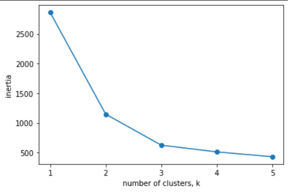

Then running the K-mean algorithm with parameter k = 3, the result is as figure below

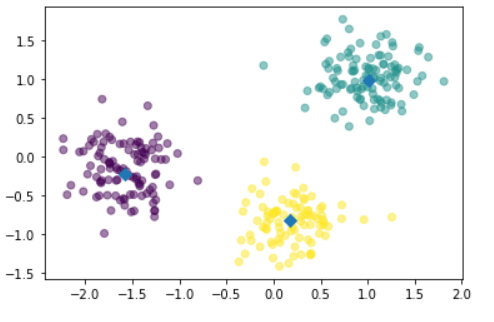

# Set up

```python
import pandas as pd
import matplotlib.pyplot as plt
import numpy as np
```

```python
# Sklearn
from sklearn.cluster import KMeans
from sklearn.pipeline import make_pipeline
from sklearn.preprocessing import StandardScaler
from sklearn.cluster import KMeans
from sklearn.pipeline import make_pipeline
from sklearn.preprocessing import StandardScaler
from sklearn.cluster import KMeans
from sklearn.preprocessing import Normalizer
```

# Clustering for dataset exploration

## Points Datatset

### Load Data

```python
# read data
url = 'https://raw.githubusercontent.com/vtn13042000/supervise_learning/main/new_points.csv'
new_points = pd.read_csv(url, header = None)

url = 'https://raw.githubusercontent.com/vtn13042000/supervise_learning/main/points.csv'
points = pd.read_csv(url, header = None)

new_points = pd.DataFrame.to_numpy(new_points)
points = pd.DataFrame.to_numpy(points)
```

### How many Cluster?

Ploting 2D data points to guess the number of cluster

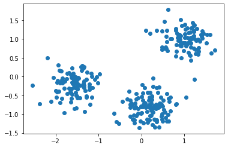

```python
xs = points[:, 0]
ys = points[:, 1]
plt.scatter(xs, ys)
```

Clustering 2D points

```python
# Create a KMeans instance with 3 clusters: model
model = KMeans(n_clusters = 3)

# Fit model to points
model.fit(points)

# Determine the cluster labels of new_points: labels
labels = model.predict(new_points)

# Print cluster labels of new_points
print(labels)
```

```
[2 0 1 2 0 2 0 0 0 1 2 0 0 1 1 0 1 1 0 0 1 0 2 0 2 1 0 1 1 2 2 0 0 0 1 2 0
 0 2 0 1 2 2 1 2 0 1 1 0 0 0 0 1 1 2 2 1 1 1 2 2 0 0 0 2 0 1 0 2 1 2 2 2 0
 2 1 1 2 0 1 2 1 2 0 1 0 1 2 0 0 0 2 0 0 2 1 1 1 1 2 0 2 1 1 2 2 0 2 1 1 2
 1 1 1 0 0 0 0 1 1 0 2 0 1 0 2 1 0 1 1 0 1 0 1 2 0 2 2 0 1 2 0 2 2 1 0 0 2
 1 2 1 0 2 1 1 2 1 0 0 1 0 1 1 0 0 2 0 0 1 2 1 2 2 0 2 0 0 2 2 1 2 2 2 1 0
 0 2 1 2 1 1 0 0 0 2 0 0 0 1 1 2 0 2 2 2 1 0 0 0 0 0 0 1 1 0 1 1 1 1 0 1 1
 0 0 2 1 2 2 1 2 1 2 1 0 0 1 0 0 0 1 2 2 1 0 0 1 0 1 1 0 1 1 2 1 2 2 2 0 1
 1 1 2 0 2 1 2 1 1 0 2 2 2 1 0 0 0 2 0 1 1 0 2 2 1 2 2 1 2 0 2 1 1 1 1 0 1
 1 0 0 2]
```

Inspect your clustering

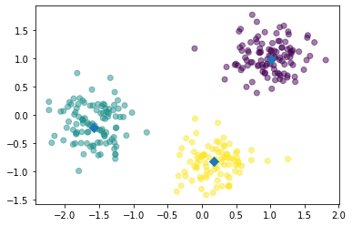

```python
# Assign the columns of new_points: xs and ys
xs = new_points[:, 0]
ys = new_points[:, 1]

# Make a scatter plot of xs and ys, using labels to define the colors
plt.scatter(xs, ys, c = labels, alpha = 0.5)

# Assign the cluster centers: centroids
centroids = model.cluster_centers_

# Assign the columns of centroids: centroids_x, centroids_y
centroids_x = centroids[:,0]
centroids_y = centroids[:,1]

# Make a scatter plot of centroids_x and centroids_y
plt.scatter(centroids_x, centroids_y, marker = "D", s = 50)
plt.show()
```

## Grains Dataset

### Load Data

```python
url = 'https://raw.githubusercontent.com/vtn13042000/supervise_learning/main/seeds.csv'
seeds = pd.read_csv(url, header = None)
seeds.head()
```

|  | 0 | 1 | 2 | 3 | 4 | 5 | 6 | 7 |
| --- | --- | --- | --- | --- | --- | --- | --- | --- |
| 0 | 15.26 | 14.84 | 0.8710 | 5.763 | 3.312 | 2.221 | 5.220 | 1 |
| 1 | 14.88 | 14.57 | 0.8811 | 5.554 | 3.333 | 1.018 | 4.956 | 1 |
| 2 | 14.29 | 14.09 | 0.9050 | 5.291 | 3.337 | 2.699 | 4.825 | 1 |
| 3 | 13.84 | 13.94 | 0.8955 | 5.324 | 3.379 | 2.259 | 4.805 | 1 |
| 4 | 16.14 | 14.99 | 0.9034 | 5.658 | 3.562 | 1.355 | 5.175 | 1 |

```python
samples = pd.DataFrame.to_numpy(seeds)
```

```python
labels = np.array([2, 2, 2, 2, 2, 2, 2, 2, 2, 2, 2, 2, 2, 2, 2, 2, 1, 2, 2, 1, 2, 2,
       2, 2, 2, 2, 1, 2, 2, 2, 2, 2, 2, 2, 2, 2, 2, 0, 2, 1, 2, 2, 2, 2,
       2, 2, 2, 2, 2, 2, 2, 2, 2, 2, 2, 2, 2, 2, 2, 2, 1, 1, 1, 1, 2, 2,
       2, 2, 2, 1, 0, 0, 0, 0, 0, 0, 0, 0, 0, 0, 0, 0, 0, 0, 0, 0, 0, 0,
       0, 0, 0, 0, 0, 0, 0, 0, 0, 0, 0, 0, 2, 0, 0, 0, 0, 0, 0, 0, 0, 0,
       0, 0, 0, 0, 0, 0, 0, 0, 0, 0, 0, 0, 2, 0, 2, 0, 0, 0, 0, 0, 0, 0,
       2, 2, 2, 2, 0, 2, 2, 2, 1, 1, 1, 1, 1, 1, 1, 1, 1, 1, 1, 1, 1, 1,
       1, 1, 1, 1, 1, 1, 1, 1, 1, 1, 1, 1, 1, 1, 1, 1, 1, 1, 1, 1, 1, 1,
       1, 1, 1, 2, 1, 1, 1, 1, 1, 1, 1, 1, 1, 1, 1, 1, 1, 1, 1, 1, 1, 1,
       1, 1, 1, 2, 1, 1, 1, 1, 1, 1, 1, 1])
```

```python
url = 'https://raw.githubusercontent.com/vtn13042000/supervise_learning/main/varieties.csv'
varieties = pd.read_csv(url, header = None)
varieties = varieties.values.tolist()
varieties = [item for sublist in varieties for item in sublist]
```

### How many clusters of grain?

Since it's unable to plot 8D points on a graph to guess the number of cluster, we will use "Elbow" method as mention above.

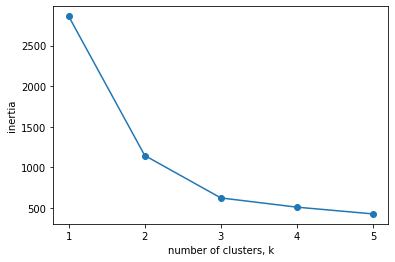

```python
ks = range(1, 6)
inertias = []

for k in ks:
    # Create a KMeans instance with k clusters: model
    model = KMeans(n_clusters = k)

    # Fit model to samples
    model.fit(samples)

    # Append the inertia to the list of inertias
    inertias.append(model.inertia_)

# Plot ks vs inertias
plt.plot(ks, inertias, '-o')
plt.xlabel('number of clusters, k')
plt.ylabel('inertia')
plt.xticks(ks)
plt.show()
```

Then 3 is the optimal value of k

Evaluating the grain clustering

```python
# Create a KMeans model with 3 clusters: model
model = KMeans(n_clusters = 3)

# Use fit_predict to fit model and obtain cluster labels: labels
labels = model.fit_predict(samples)

# Create a DataFrame with labels and varieties as columns: df
df = pd.DataFrame({'labels': labels, 'varieties': varieties})

# Create crosstab: ct
ct = pd.crosstab(index = df['labels'], columns = df['varieties'])

# Display ct
print(ct)
```

```
varieties  Canadian wheat  Kama wheat  Rosa wheat
labels
0                       0          64          10
1                      70           5           0
2                       0           1          60
```

## Fish Dataset

### Load Data

```python
# read data
url1 = 'https://assets.datacamp.com/production/repositories/655/datasets/fee715f8cf2e7aad9308462fea5a26b791eb96c4/fish.csv'
fish = pd.read_csv(url1, header = None)
print(fish.columns)
display(fish.head())
```

```
Int64Index([0, 1, 2, 3, 4, 5, 6], dtype='int64')
```

|  | 0 | 1 | 2 | 3 | 4 | 5 | 6 |
| --- | --- | --- | --- | --- | --- | --- | --- |
| 0 | Bream | 242.0 | 23.2 | 25.4 | 30.0 | 38.4 | 13.4 |
| 1 | Bream | 290.0 | 24.0 | 26.3 | 31.2 | 40.0 | 13.8 |
| 2 | Bream | 340.0 | 23.9 | 26.5 | 31.1 | 39.8 | 15.1 |
| 3 | Bream | 363.0 | 26.3 | 29.0 | 33.5 | 38.0 | 13.3 |
| 4 | Bream | 430.0 | 26.5 | 29.0 | 34.0 | 36.6 | 15.1 |

```python
labels = np.array([3, 1, 1, 1, 1, 1, 1, 1, 1, 1, 1, 1, 1, 1, 1, 1, 1, 1, 1, 1, 1, 1,
       1, 1, 1, 1, 1, 1, 1, 1, 1, 1, 1, 1, 3, 3, 3, 3, 3, 3, 3, 3, 3, 3,
       3, 3, 3, 3, 3, 3, 3, 3, 3, 1, 0, 0, 0, 0, 0, 0, 0, 0, 0, 0, 0, 0,
       3, 0, 2, 2, 2, 2, 2, 2, 2, 2, 2, 2, 2, 2, 2, 2, 2, 2, 2])
```

```python
species = fish[0]
```

```python
samples = fish.drop([0], axis=1)
samples = pd.DataFrame.to_numpy(samples)
samples[0]
```

```
array([242. ,  23.2,  25.4,  30. ,  38.4,  13.4])
```

### Scaling fish data for clustering

```python
# Create scaler: scaler
scaler = StandardScaler()

# Create KMeans instance: kmeans
kmeans = KMeans(n_clusters = 4)

# Create pipeline: pipeline
pipeline = make_pipeline(scaler, kmeans)
```

Clustering the fish data

```python
# Fit the pipeline to samples
pipeline.fit(samples)

# Calculate the cluster labels: labels
labels = pipeline.predict(samples)

# Create a DataFrame with labels and species as columns: df
df = pd.DataFrame({'labels': labels, 'species': species})

# Create crosstab: ct
ct = pd.crosstab(df['labels'], df['species'])

# Display ct
print(ct)
```

```
species  Bream  Pike  Roach  Smelt
labels
0            1     0     19      1
1            0     0      0     13
2            0    17      0      0
3           33     0      1      0
```

## Stocks Dataset

### Load Data

```python
url = 'https://assets.datacamp.com/production/repositories/655/datasets/1304e66b1f9799e1a5eac046ef75cf57bb1dd630/company-stock-movements-2010-2015-incl.csv'
stock = pd.read_csv(url)
print(stock.info())
display(stock.head())
```

```
<class 'pandas.core.frame.DataFrame'>
RangeIndex: 60 entries, 0 to 59
Columns: 964 entries, Unnamed: 0 to 2013-10-29
dtypes: float64(963), object(1)
memory usage: 452.0+ KB
None
```

|  | Unnamed: 0 | 2010-01-04 | 2010-01-05 | 2010-01-06 | 2010-01-07 | 2010-01-08 | 2010-01-11 | 2010-01-12 | 2010-01-13 | 2010-01-14 | 2010-01-15 | 2010-01-19 | 2010-01-20 | 2010-01-21 | 2010-01-22 | 2010-01-25 | 2010-01-26 | 2010-01-27 | 2010-01-28 | 2010-01-29 | 2010-02-01 | 2010-02-02 | 2010-02-03 | 2010-02-04 | 2010-02-05 | 2010-02-08 | 2010-02-09 | 2010-02-10 | 2010-02-11 | … |
| --- | --- | --- | --- | --- | --- | --- | --- | --- | --- | --- | --- | --- | --- | --- | --- | --- | --- | --- | --- | --- | --- | --- | --- | --- | --- | --- | --- | --- | --- | --- |
| 0 | Apple | 0.580000 | -0.220005 | -3.409998 | -1.170000 | 1.680011 | -2.689994 | -1.469994 | 2.779997 | -0.680003 | -4.999995 | 6.709993 | -3.180006 | -4.009998 | -9.030006 | 0.560000 | -0.010000 | 1.030010 | -5.640009 | -9.019993 | 2.360001 | -0.050001 | 4.060000 | -4.680000 | 2.829998 | -1.570009 | -0.229992 | -0.769990 | 3.789993 | … |
| 1 | AIG | -0.640002 | -0.650000 | -0.210001 | -0.420000 | 0.710001 | -0.200001 | -1.130001 | 0.069999 | -0.119999 | -0.500000 | 0.200001 | -0.100000 | -0.460001 | -1.190001 | -0.650000 | -1.300001 | 0.430000 | -1.690000 | -0.300001 | -0.420000 | -0.020001 | -0.099998 | -0.940001 | -0.090000 | -0.250000 | 0.760000 | 3.710001 | -0.200001 | … |
| 2 | Amazon | -2.350006 | 1.260009 | -2.350006 | -2.009995 | 2.960006 | -2.309997 | -1.640007 | 1.209999 | -1.790001 | -2.039994 | 1.300003 | -1.349998 | -0.639999 | -4.169998 | -1.790000 | -1.079995 | 1.720001 | 1.599999 | -4.360000 | -4.309997 | -0.669998 | 1.979995 | -2.699997 | 1.510002 | -2.549995 | -0.169998 | -0.639999 | 2.879997 | … |
| 3 | American express | 0.109997 | 0.000000 | 0.260002 | 0.720002 | 0.190003 | -0.270001 | 0.750000 | 0.300004 | 0.639999 | -0.130001 | 0.719997 | 0.050000 | -0.830002 | -2.770001 | -1.309997 | 0.559997 | 0.709999 | -1.239998 | 0.060002 | 0.369999 | 0.340000 | -0.579998 | -0.500000 | 0.189998 | -0.969997 | 0.270001 | 0.169998 | 0.480000 | … |
| 4 | Boeing | 0.459999 | 1.770000 | 1.549999 | 2.690003 | 0.059997 | -1.080002 | 0.360000 | 0.549999 | 0.530002 | -0.709999 | 0.050004 | -0.130001 | -1.099998 | -0.849999 | -0.569999 | 0.169998 | 3.090000 | 0.409999 | -2.200001 | 0.959999 | 0.649998 | -0.060001 | -1.630001 | -0.809997 | -0.440003 | 1.120003 | -0.169998 | 0.840000 | … |

5 rows × 964 columns

```python
companies = stock['Unnamed: 0']
companies = companies.to_list()
```

```python
df1 = stock.drop(['Unnamed: 0'], axis = 1)
movements = pd.DataFrame.to_numpy(df1)
```

```python
labels = np.array([4, 1, 4, 1, 3, 1, 9, 5, 7, 2, 7, 1, 7, 7, 4, 0, 1, 4, 1, 9, 1, 5,
       5, 4, 4, 8, 1, 2, 2, 3, 4, 4, 4, 4, 5, 0, 3, 9, 2, 8, 2, 8, 9, 4,
       7, 5, 9, 4, 5, 9, 4, 4, 9, 7, 3, 1, 6, 7, 1, 0])
```

### Clustering the stocks using KMeans

```python
# Create a normalizer: normalizer
normalizer = Normalizer()

# Create a KMeans model with 10 clusters: kmeans
kmeans = KMeans(n_clusters = 10)

# Make a pipeline chaining normalizer and kmeans: pipeline
pipeline = make_pipeline(normalizer, kmeans)

# Fit pipeline to the daily price movements
pipeline.fit(movements)
```

```
Pipeline(memory=None,
         steps=[('normalizer', Normalizer(copy=True, norm='l2')),
                ('kmeans',
                 KMeans(algorithm='auto', copy_x=True, init='k-means++',
                        max_iter=300, n_clusters=10, n_init=10, n_jobs=None,
                        precompute_distances='auto', random_state=None,
                        tol=0.0001, verbose=0))],
         verbose=False)
```

Which stocks move together?

```python
# Predict the cluster labels: labels
labels = pipeline.predict(movements)

# Create a DataFrame aligning labels and companies: df
df = pd.DataFrame({'labels': labels, 'companies': companies})

# Display df sorted by cluster label
print(df.sort_values('labels'))
```

```
    labels                           companies
56       0                            Wal-Mart
0        1                               Apple
51       1                   Texas instruments
50       1  Taiwan Semiconductor Manufacturing
33       1                           Microsoft
24       1                               Intel
11       1                               Cisco
14       1                                Dell
48       2                              Toyota
45       2                                Sony
34       2                          Mitsubishi
58       2                               Xerox
22       2                                  HP
21       2                               Honda
```

[output cut: 46 more lines]